# Coastal Area Visitation Brief 2011-2020

Lauren Pandori

### Trail Counters Deployed 2011-2020

1. How many people visit the coastal area each year?
2. Does visitation differ across days of the week?
3. Is visitation higher on days with low tides (less than 0.7 ft) during park hours?
4. Is visitation higher on holidays?

### Annual coastal area visits

```r
# make visit_est into an interactive table
visit_table <- visit_est %>%
  # more human-friendly table layout
  pivot_wider(names_from = 'Location', values_from = 'Visitors') %>%
  # some math for total visitation to coastal area
  mutate(`Coastal area` = round(`Lot 1` + `Lot 2`, digits = 0),
         # math to get percent of visitors to coastal area
         `Percent of all visitors in coastal area` = round(`Coastal area`/(`Coastal area` + `Entrance station`)*100, digits = 0)) %>%
  # select relevant columns in order to be presented
  select(Year, `Entrance station`, `Coastal area`, `Percent of all visitors in coastal area`) %>%
  # rename some values
  rename(`Entrance station visitors` = `Entrance station`, `Coastal area visitors` = `Coastal area`)

# create formatted table
formattable(visit_table,
            # L justify columns
            align = 'l',
            # column list for custom formatting
            list(
            # create bar for % of total visitors to coastal area
            `Percent total visitors to coastal area` = color_bar
            (cal_palette('tidepool')[1])))
```

| Year | Entrance station visitors | Coastal area visitors | Percent of all visitors in coastal area |
| --- | --- | --- | --- |
| 2011 | 813351 | 298670 | 27 |
| 2012 | 877951 | 331444 | 27 |
| 2013 | 856128 | 339537 | 28 |
| 2014 | 893434 | 315902 | 26 |
| 2015 | 981825 | 394498 | 29 |
| 2016 | 959145 | 443965 | 32 |
| 2017 | 997903 | 414093 | 29 |
| 2018 | 842104 | 407566 | 33 |
| 2019 | 761485 | 379503 | 33 |
| 2020 | 523878 | 380920 | 42 |

```r
remove(visit_table, visit_est2)
```

### Visitation is highest on weekends

- Visitation highest on weekend days (Saturday and Sunday)
- Midweek visitation (Tuesday-Thursday) is lower than weekend edge days (Monday and Friday)

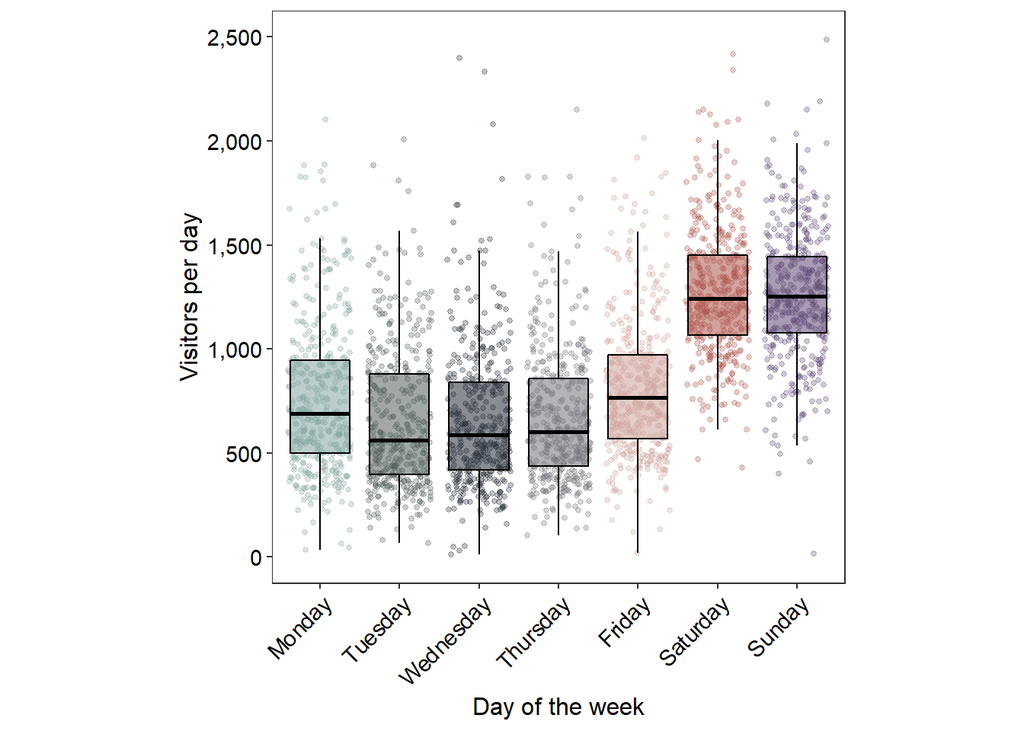

```r
# what this needs: weekday, lltheme_light

# setup plot
ggplot(data = filter(weekday, lot == 'Lot 1' & events >= 10),
                   mapping = aes(x = dow, y = events, fill = dow,
                                 color = dow, alpha = 0.2)) +
              geom_jitter(alpha = 0.3, size = 1) +

              coord_cartesian(ylim = c(0,2500)) +
              scale_y_continuous(labels = scales::label_number(big.mark = ',')) +
              scale_color_manual(values = cal_palette(name = 'tidepool', n = 7,
                                                      type = 'continuous')) +
              scale_fill_manual(values = cal_palette(name = 'tidepool', n = 7,
                                                      type = 'continuous')) +
              xlab('Day of the week') +
              ylab('Visitors per day') +
         geom_boxplot(color = 'black', outlier.shape = NA) +
         lltheme_light +
         theme(legend.position = 'none',
               panel.grid.major = element_blank(),
               panel.grid.minor = element_blank(),
               axis.text = element_text(size = 12, hjust = 1, color = 'black'),
               axis.text.x = element_text(angle = 45),
               aspect.ratio = 1)
```

#### Tide level is unrelated to visitation

- The number of visitors isn’t higher during advertised “good” low tide events, where the tide level is less than 0.7 ft above Mean Lower Low Water (MLLW)
- Visitors may be unaware of tide levels before visiting

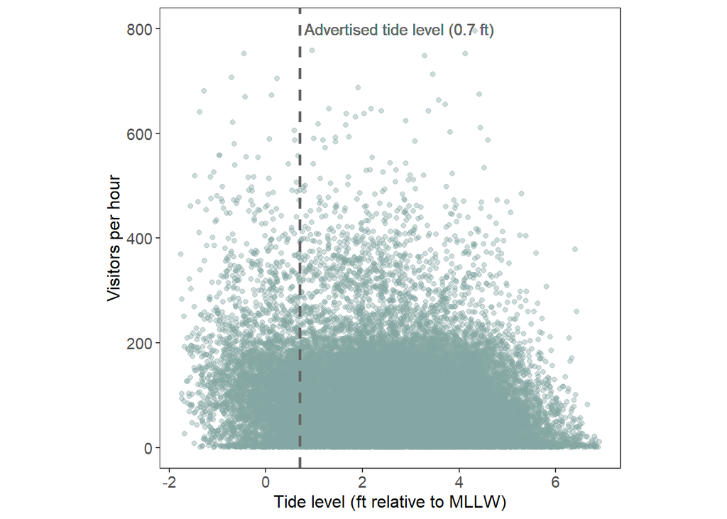

```r
ggplot(data = filter(hr_tide, lot == 'Lot 1'),
                     mapping = aes(x = (tidelvl*3.2808399),
                                   y = events)) +
  geom_point(color = cal_palette('tidepool')[1], alpha = 0.4) +
  geom_vline(xintercept = 0.7, linetype = 'dashed', color = 'gray40', size = 1) +
  geom_text(mapping = aes(x = 0.8, y = 800, hjust = 0,
                          label = 'Advertised tide level (0.7 ft)'), color = 'gray40') +
  coord_cartesian(ylim = c(0,800)) +
  scale_x_continuous(breaks = scales::pretty_breaks()) +
  xlab('Tide level (ft relative to MLLW)') +
  ylab('Visitors per hour') +
  lltheme_light +
  theme(aspect.ratio = 1)
```

#### Most holidays draw more visitors

We compared the number of visitors on holidays paired with non-holidays that were 14 days after holidays. We included some holiday-adjacent days, such as the day after Thanksgiving, because staff noted high visitation on those days.

The plot below shows the difference in the number of visitors between holidays and paired non-holidays. Stars indicate significant differences in visitation (paired t-test p < 0.05).

- There were more visitors on most holidays
- Some holidays, such as Martin Luther King Jr. Day and Veterans Day are also fee-free days

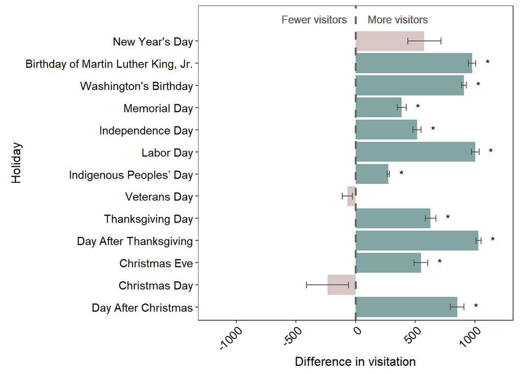

```r
ggplot(data = filter(holiday_test, lot == 'Lot 1')) +
  geom_col(mapping = aes(y = mean_dif, x = fct_rev(holiday), fill = pval_sig)) +
  geom_errorbar(mapping = aes(x = fct_rev(holiday), ymin = (mean_dif - se_dif),
                              ymax = (mean_dif + se_dif), width = 0.3),
                color = 'gray30') +
  scale_fill_manual(values = c(cal_palette('tidepool')[4], cal_palette('tidepool')[1])) +
  geom_text(mapping = aes(x = 14, y = -100, label = 'Fewer visitors'),
            color = 'gray40', hjust = 0.95, size = 3.5) +
  geom_text(mapping = aes(x = 14, y = 100, label = 'More visitors'),
            color = 'gray40', hjust = 0, size = 3.5) +
  geom_text(data = filter(holiday_test, lot == 'Lot 1' & pval_sig == TRUE),
            mapping = aes(x = fct_rev(holiday), y = (mean_dif + se_dif + 100),
                          label = '*'), color = 'black') +
  geom_hline(yintercept = 0, linetype = 'dashed', color = 'gray40', size = 1) +
  coord_flip(xlim = c(1,14)) +
  scale_y_continuous(breaks = seq(-1000,1000, by = 500), limits = c(-1200,1200)) +
  ylab('Difference in visitation') +
  xlab('Holiday') +
  lltheme_light +
  theme(legend.position = 'none',
        panel.grid = element_blank(),
        text = element_text(color = 'black', size = 12),
        axis.text = element_text(color = 'black'),
        axis.text.x = element_text(angle = 45, hjust = 1),
        aspect.ratio = 1)
```